# Deep Learning Homework #1

## Homework #1

## July 5, 2023

### Question #1

**Paper Critique**

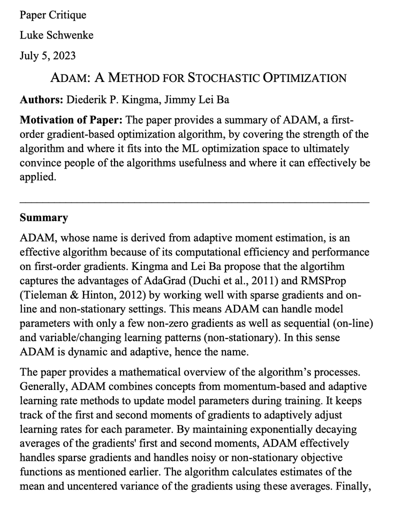

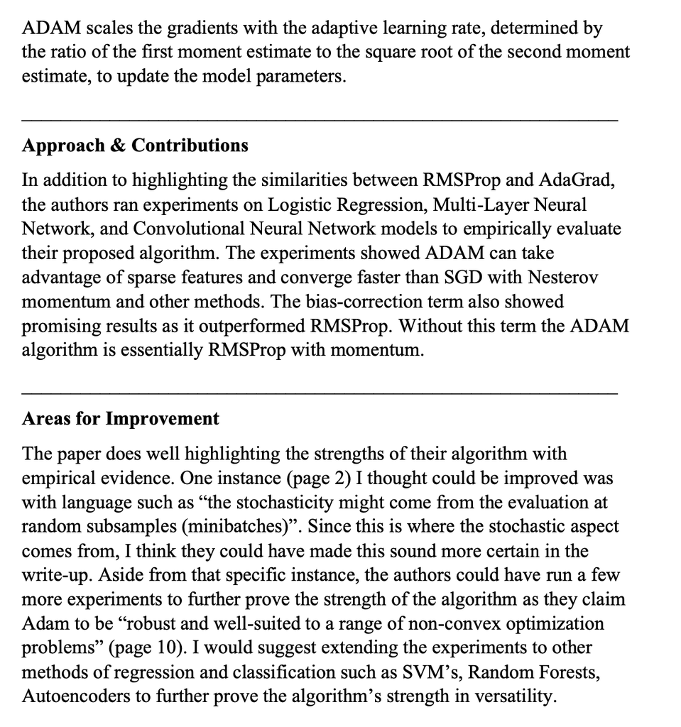

### Question #2

Train two different models using sklearn to learn each of the following gates below: Logistic Regression, Support Vector Machine (SVC). Note: To learn the above gates you will need 100% accuracy on the training data. If a gate cannot be learned by the model mention the reason why

Gates:

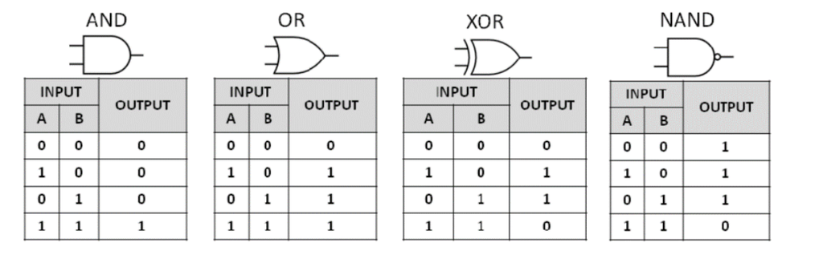

```python
import numpy as np
from sklearn.linear_model import LogisticRegression
from sklearn.svm import SVC
from sklearn.metrics import accuracy_score
```

#### Logistic Regression

```python
import warnings
warnings.filterwarnings("ignore")

gates = {
    'AND': (np.array([[0, 0], [1, 0], [0, 1], [1, 1]]), np.array([0, 0, 0, 1])),
    'OR': (np.array([[0, 0], [1, 0], [0, 1], [1, 1]]), np.array([0, 1, 1, 1])),
    'XOR': (np.array([[0, 0], [1, 0], [0, 1], [1, 1]]), np.array([0, 1, 1, 0])),
    'NAND': (np.array([[0, 0], [1, 0], [0, 1], [1, 1]]), np.array([1, 1, 1, 0]))
}

# Iterate through the gates
for gate, (X, Y) in gates.items():

    print(f"Gate: {gate}")
    print('\n')
    print(f"X Values:")
    print(X)
    print(f"Y Values:")
    print(Y)
    print('\n')

    # Logistic Regression
    logistic_regression = LogisticRegression()
    logistic_regression.fit(X, Y)

    # Predict using logistic regression
    y_pred_lr = logistic_regression.predict(X)
    accuracy_lr = accuracy_score(Y, y_pred_lr)
    print("Logistic Regression Accuracy:", accuracy_lr)

    # Support Vector Machine
    svm = SVC(kernel='rbf')
    svm.fit(X, Y)

    # Predict using SVM
    y_pred_svm = svm.predict(X)
    accuracy_svm = accuracy_score(Y, y_pred_svm)
    print("SVM Accuracy:", accuracy_svm)
    print('\n')
    print('------------------------------------')
    print('\n')
```

```
Gate: AND


X Values:
[[0 0]
 [1 0]
 [0 1]
 [1 1]]
Y Values:
[0 0 0 1]


Logistic Regression Accuracy: 0.75
SVM Accuracy: 1.0


------------------------------------


Gate: OR


X Values:
[[0 0]
 [1 0]
 [0 1]
 [1 1]]
Y Values:
[0 1 1 1]


Logistic Regression Accuracy: 0.75
SVM Accuracy: 1.0


------------------------------------


Gate: XOR

```

[output cut: 19 more lines]

```

X Values:
[[0 0]
 [1 0]
 [0 1]
 [1 1]]
Y Values:
[1 1 1 0]


Logistic Regression Accuracy: 0.75
SVM Accuracy: 1.0


------------------------------------
```

**Summary:** The SVM with the RBF can learn all of the gates with 100% accuracy. This is because SVM is able to separate data in ways Logistic regression cannot in these scenarios. Logistic Regression on the other hand has sub-100% accuracy on all Gates. This is because it cannot handle non-linear problems like the SVM RBF kernel can.

**In order to see more results and effects of these models, consider simulating additional data.**

### Question #3

Use randomly generated data to demonstrate how the ROC curve differs from (Precision-Recall) PR curve for unbalanced datasets. Plot both curves on different levels of imbalance between the two classes (e.g. 50/50, 75/25, 90/10). Summarize your observations.

```python
import numpy as np
import matplotlib.pyplot as plt
from sklearn.metrics import roc_curve, precision_recall_curve, average_precision_score, roc_auc_score
```

[figure not shown]

```python
def generate_data(imbalance_ratio):
    np.random.seed(42)
    n_samples = 1000
    n_positive = int(n_samples * imbalance_ratio)
    n_negative = n_samples - n_positive
    positive_labels = np.ones(n_positive)
    negative_labels = np.zeros(n_negative)
    y_true = np.concatenate((positive_labels, negative_labels))
    y_scores = np.random.rand(n_samples)
    return y_true, y_scores

imbalance_ratios = [0.5, 0.25, 0.1]

plt.figure(figsize=(18, 6))
plt.subplots_adjust(wspace=0.3)

for i, imbalance_ratio in enumerate(imbalance_ratios):
    y_true, y_scores = generate_data(imbalance_ratio)

    plt.subplot(1, 3, i + 1)
    plt.title(f"Imbalance Ratio: {imbalance_ratio}")

    # ROC Curve
    fpr, tpr, _ = roc_curve(y_true, y_scores)
    roc_auc = auc(y_true, y_scores)
    plt.plot(fpr, tpr, label=f"ROC Curve (AUC = {roc_auc:.3f})")
    plt.xlabel('False Positive Rate')
    plt.ylabel('True Positive Rate')

    # PR Curve
    precision, recall, _ = precision_recall_curve(y_true, y_scores)
    pr_ap = auc(recall, precision)
    plt.plot(recall, precision, label=f"PR Curve (AP = {pr_ap:.3f})")
    plt.xlabel('Recall & False Positive Rate')
    plt.ylabel('Precision & True Positive Rate')

    plt.legend()

plt.show()
```

The above code shows the ROC and PR curves for 3 levels of imbalanced class artificial datasets: 50/50, 75/25, and 90/10. The 90/10 is the most imbalanced.

**Precision Recall (PR) Curve Results Summary:** As the level of imbalance increases, the average precision decreases. This is because the training data was randomly generated. Since the class imbalance is more directly shown in these plots, PR curves are a better choice when determinining imbalanced model effectiveness.

### Question #4

Design an optimal solution and submit a screenshot with the neural network architecture and hyperparameters for the below classification problem (20). Summarize your design in a few statements. Reference: https://playground.tensorflow.org/

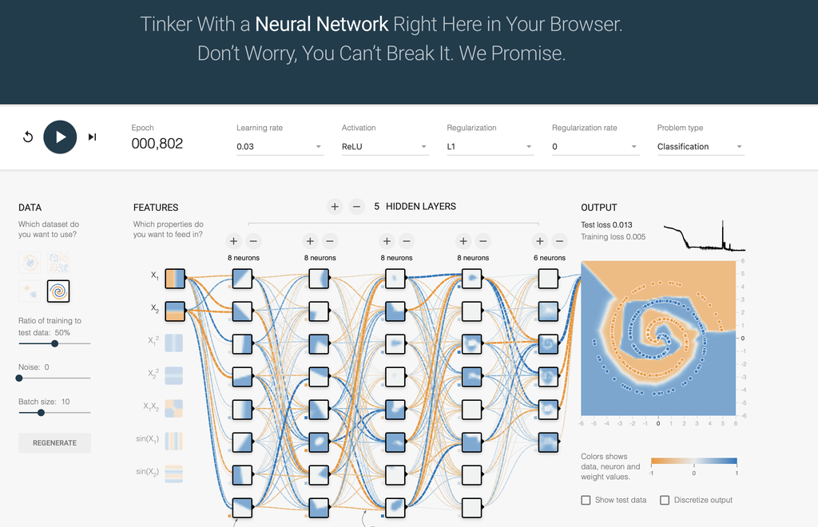

**Architecture Summary:**

The model above takes 2 input features, and passes it to a neural network. The network has 5 hidden layers. The first 4 layers have 8 neurons each and the 5th one has 6. The learning rate is set to 0.03 which is not super small. The ReLU non-linear activation is used for each of the hidden layers. The output classifies to data into the yellow or blue classes.